# Discovering viruses in ‘uncharted’ territories

2024-11-14

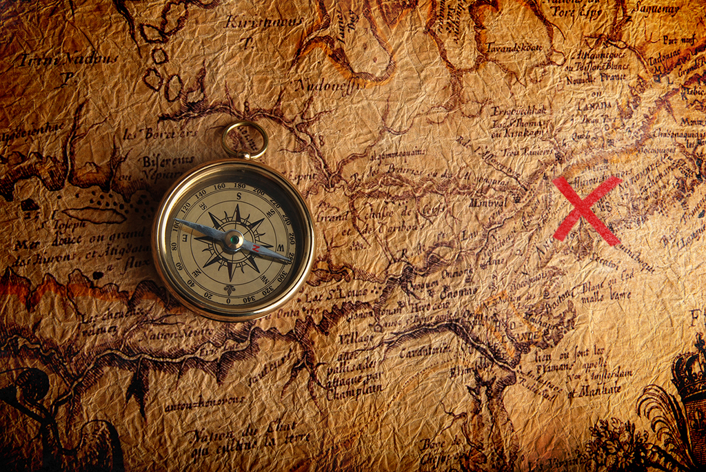

## **Introduction**

- There are many research projects conducted on vastly different organisms that are not related to virus research. Because the focus on a given research task does not involve the detection or discovery of viruses, this is often overlooked and provides an opportunity for virologists to comb through the data and see if viruses are present.
- Given that each organism present on plant Earth is estimated to be infected by at least one virus, this provides ample opportunity to discover novel viruses in a host of interest.
- Not only is this conceptual, but this as been applied in a variety of hosts. I will focus on viruses isolated from roses in this case.

## **From the literature**

- In roses:

[figure not shown]

- **RVC** was found by looking through transcriptome data
- This can help in the future as growers and diagnosticians decide which viruses they should screen for.

Reference: Xing, F., Gao, D., Habili, N., Wang, H., Zhang, Z., Cao, M., & Li, S. (2021). Identification and molecular characterization of a novel carlavirus infecting rose plants (Rosa chinensis Jacq.). Archives of Virology, 166, 3499-3502.

## **Research Questions**

1. Are there novel viruses that have not yet been characterized but were sequenced as a “byproduct” of some other experimental focus?
2. Are there viruses that are capable of infecting roses that have not yet been reported, but have been sequenced “serendipitously” by HTS methods?

## **Predictions/expected outcomes**

- I am hopeful to develop a useful tool for analyzing both our own and publicly available HTS data.
- In practice, this could be used for any plant host to determine if there are novel or unreported viruses.
- Ideally, it would be useful to create a pipeline where we can quickly evaluate multiple samples concurrently.

## **Overview of the project**

1. Obtain SRA data (RNA-seq)
2. Download reference genome/s
3. QC and trimming of raw SRA data
4. Reference mapping of reads to host genome
5. Gather unmapped reads using the flags
6. Assembly of reads (rnaSPADES)
7. Create a database of viruses for nucleotide blast
8. Use Diamond for nucleotide-to-protein blasting
9. Evaluate results of unmapped reads

## 1. Obtain SRA data (RNA-seq)

- `Fastq dump` was used to obtain data associated with specific accessions
- Steps: **1)** NCBI **2)** SRA **3)** search species **4)** download accession list

[NCBI link for *Rosa chinensis*](https://www.ncbi.nlm.nih.gov/sra/?term=Rosa+chinensis)

1. sh file
2. sbatch script
3. .args

## 2. Download reference genome/s

- In this case, we will use the *Rosa chinensis* genome as a reference. This reference corresponds with the RNA-seq data downloaded in the previous section.
- Steps: **1)** Go to NCBI **2)** Go the genomes **3)** Search organism of interest **4)** Select FTP **5)** Copy link for file of interest (in our case, we will copy the link for both `genomic.fna.gz` and `genomic.gff.gz`)

[LINK to download reference genome](https://ftp.ncbi.nlm.nih.gov/genomes/all/GCA/002/994/745/)

1. sh script
2. sbatch file

## 3. `QC` and trimming of raw SRA data

- Here we are only looking at one sample, which is `SRR29872023_1` and `SRR29872023_2`. If we wanted to use an array system, we could look at all of the files and have `fastqc` run for each of them.

1. sbatch file
2. sh script

## 3. `QC` and trimming of raw SRA data

[interactive chart not shown]

## 3. `QC` and trimming of raw SRA data

[interactive chart not shown]

## 3. QC and `trimming` of raw SRA data

1. sh script
2. sbatch file

## 4. Reference mapping of reads to host genome

- Usually, we would use BWA (currently called `minimap2`) to map reads to a reference genome. We will be using `Hisat2` for read mapping because this program is optimized for mapping RNA reads onto a DNA genome.
- Steps: **1)** Create a reference index of the reference sequence **2)** Map raw, trimmed, or de novo assembled reads to the indexed reference sequence **3)** Generate a `.SAM` file (Simple Alignment format) **4)** Convert the `.SAM` to a `.BAM` (Binary alignment format) **5)** Sort the `.BAM` file.

## 4. Reference mapping of reads to host genome

1. creating a new environment

```
conda create -n hisat2_env
```

1. activate the environment

```
conda activate hisat2_env
```

## 4. Reference mapping of reads to host genome

1. sh script
2. sbatch file
3. sh script
4. sbatch file

## 4. Reference mapping of reads to host genome

| x |
| --- |
| 48805428 + 0 in total (QC-passed reads + QC-failed reads) |
| 1532032 + 0 secondary |
| 0 + 0 supplementary |
| 0 + 0 duplicates |
| 43288907 + 0 mapped (88.70% : N/A) |
| 47273396 + 0 paired in sequencing |
| 23636698 + 0 read1 |
| 23636698 + 0 read2 |
| 39080286 + 0 properly paired (82.67% : N/A) |
| 39441476 + 0 with itself and mate mapped |
| 2315399 + 0 singletons (4.90% : N/A) |
| 171226 + 0 with mate mapped to a different chr |
| 152303 + 0 with mate mapped to a different chr (mapQ>=5) |

## 4. Reference mapping of reads to host genome

| x |
| --- |
| BamQC report |
| ———————————– |
| >>>>>>> Input |
| bam file = /scratch/biol726310/BIOL7263_Genomics/rrv_project/sorted_hisat2.bam |
| outfile = /scratch/biol726310/BIOL7263_Genomics/rrv_project/bamqc/genome_results.txt |
| >>>>>>> Reference |
| number of bases = 515,588,973 bp |
| number of contigs = 55 |
| >>>>>>> Globals |
| number of windows = 454 |
| number of reads = 47,273,396 |
| number of mapped reads = 41,756,875 (88.33%) |
| number of secondary alignments = 1,532,032 |
| number of mapped paired reads (first in pair) = 20,965,602 |
| number of mapped paired reads (second in pair) = 20,791,273 |
| number of mapped paired reads (both in pair) = 39,441,476 |
| number of mapped paired reads (singletons) = 2,315,399 |
| number of mapped bases = 30,019,458,809 bp |
| number of sequenced bases = 6,217,039,734 bp |

## 4. Reference mapping of reads to host genome

| x |
| --- |
| 23636698 reads; of these: |
| 23636698 (100.00%) were paired; of these: |
| 4096555 (17.33%) aligned concordantly 0 times |
| 19022555 (80.48%) aligned concordantly exactly 1 time |
| 517588 (2.19%) aligned concordantly >1 times |
| —- |
| 4096555 pairs aligned concordantly 0 times; of these: |
| 70100 (1.71%) aligned discordantly 1 time |
| —- |
| 4026455 pairs aligned 0 times concordantly or discordantly; of these: |
| 8052910 mates make up the pairs; of these: |
| 5516521 (68.50%) aligned 0 times |
| 2441427 (30.32%) aligned exactly 1 time |
| 94962 (1.18%) aligned >1 times |
| 88.33% overall alignment rate |

## 5. Gather unmapped reads using the flags

- After mapping the reads to the host genome (remove unnecessary reads), we can use the samtools `flag` command to extract unmapped reads. In our case, we are interested in the unmapped reads, as these may contain virus reads and subsequent virus sequences.
- Steps: **1)** Gather the unmapped reads with the soomtools `flagstats` command **2)** convert the `.BAM` file to `fastq`.
- I was able to use both tools (bedtools and samtools) to generate fastq files from the `.BAM` file. Below are the documents submitted to OSCER:
1. sh script
2. sbatch file

## 6. Assembly of reads (rnaSPADES)

1. sh script
2. sbatch file

| x |
| --- |
| All statistics are based on contigs of size >= 500 bp, unless otherwise noted (e.g., “# contigs (>= 0 bp)” and “Total length (>= 0 bp)” include all contigs). |
| Assembly transcripts |
| # contigs (>= 0 bp) 51321 |
| # contigs (>= 1000 bp) 3542 |
| # contigs (>= 5000 bp) 39 |
| # contigs (>= 10000 bp) 0 |
| # contigs (>= 25000 bp) 0 |
| # contigs (>= 50000 bp) 0 |
| Total length (>= 0 bp) 23962415 |
| Total length (>= 1000 bp) 6046849 |
| Total length (>= 5000 bp) 226142 |
| Total length (>= 10000 bp) 0 |
| Total length (>= 25000 bp) 0 |
| Total length (>= 50000 bp) 0 |
| # contigs 11871 |
| Largest contig 7867 |
| Total length 11673416 |
| GC (%) 40.75 |
| N50 1035 |
| N75 687 |
| L50 3336 |
| L75 6846 |
| # N’s per 100 kbp 36.15 |

## 7. Create a database of viruses for blast searches

```
update_blastdb.pl --decompress nt_viruses
```

Here is the taxon ID for viruses 10239. I was able to generate a link from the Uniprotkb website that will download all of the protein sequences using the link (rather than downloading manually).

1. **.sh script**
2. **.sbatch file**

Here is the command for building the database. This step is critical as it will generate the `.dmnd` formatted file.

```
diamond makedb --in /scratch/biol726310/BIOL7263_Genomics/rrv_project/databases/protein_db/all_virus_protein -d /scratch/biol726310/BIOL7263_Genomics/rrv_project/databases/protein_db/virus_protein_db
```

## 8. Use Diamond for nucleotide-to-protein blasting

1. **.sh script**
2. **.sbatch file**
- This script contains code for both the nucleotide and protein blast. This will run each of the searches at the same time. Additionally, the code has been created to output `.csv` file, which will become more important in the following step.

## 9. Evaluate results of unmapped reads

- Using R, we manipulated the input `.csv` file to make it more user friendly, and to include important sequencing results.

## 9. Evaluate results of unmapped reads

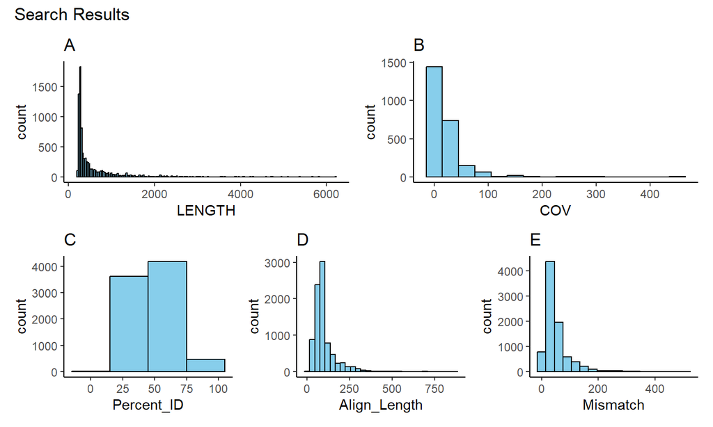

## 9. Evaluate results of unmapped reads

Arranging by LENGTH

| Seq_Title_Org | NODE | LENGTH | COV | Percent_ID | Mismatch | Evalue |
| --- | --- | --- | --- | --- | --- | --- |
| NA | 9 | 6217 | 14.05225 | 33.3 | 188 | 0 |
| OS=Acanthamoeba polyphaga moumouvirus | 9 | 6217 | 14.05225 | 30.9 | 155 | 0 |
| OS=Saudi moumouvirus | 9 | 6217 | 14.05225 | 30.9 | 155 | 0 |
| OS=Moumouvirus Monve | 9 | 6217 | 14.05225 | 30.9 | 155 | 0 |
| OS=Moumouvirus australiensis | 9 | 6217 | 14.05225 | 33.8 | 117 | 0 |
| OS=Aedes aegypti To virus 2 | 17 | 5832 | 16.36256 | 30.1 | 296 | 0 |
| OS=Lampyris noctiluca errantivirus 1 | 17 | 5832 | 16.36256 | 30.7 | 282 | 0 |
| OS=Aedes aegypti To virus 1 | 17 | 5832 | 16.36256 | 29.6 | 267 | 0 |
| OS=Chibugado virus | 17 | 5832 | 16.36256 | 27.0 | 306 | 0 |
| OS=Ceratitis capitata metavirus 2 | 17 | 5832 | 16.36256 | 29.4 | 290 | 0 |

## 9. Evaluate results of unmapped reads

Arranging by COV

| Seq_Title_Org | NODE | LENGTH | COV | Percent_ID | Mismatch | Evalue |
| --- | --- | --- | --- | --- | --- | --- |
| OS=Hokovirus HKV1 | 1770 | 1418 | 435.1115 | 93.3 | 15 | 0.000000 |
| OS=Bovine viral diarrhea virus 2 | 1770 | 1418 | 435.1115 | 83.1 | 29 | 0.000000 |
| OS=Bovine viral diarrhea virus 2 | 1770 | 1418 | 435.1115 | 91.9 | 14 | 0.000000 |
| OS=Bovine viral diarrhea virus | 1770 | 1418 | 435.1115 | 91.5 | 15 | 0.000000 |
| OS=Bovine viral diarrhea virus 2 | 1770 | 1418 | 435.1115 | 92.0 | 13 | 0.000000 |
| OS=Megaviridae environmental sample | 1679 | 1450 | 382.6333 | 54.5 | 20 | 0.000114 |
| OS=Dishui lake phycodnavirus 1 | 3664 | 977 | 314.6836 | 86.8 | 18 | 0.000000 |
| OS=Sylvanvirus sp | 3664 | 977 | 314.6836 | 72.5 | 36 | 0.000000 |
| OS=Manila clam xenomavirus | 3664 | 977 | 314.6836 | 57.0 | 50 | 0.000000 |
| OS=Marseillevirus LCMAC102 | 3664 | 977 | 314.6836 | 53.0 | 51 | 0.000000 |

## 9. Evaluate results of unmapped reads

Arranging by Percent_ID

| Seq_Title_Org | NODE | LENGTH | COV | Percent_ID | Mismatch | Evalue |
| --- | --- | --- | --- | --- | --- | --- |
| OS=Rose partitivirus | 1222 | 1687 | 29.425031 | 100 | 0 | 0 |
| OS=Rose cryptic virus 1 | 1952 | 1351 | 81.942097 | 100 | 0 | 0 |
| OS=Rose cryptic virus 1 | 2018 | 1336 | 133.779097 | 100 | 0 | 0 |
| OS=Rose cryptic virus 1 | 2785 | 1138 | 10.477934 | 100 | 0 | 0 |
| OS=Escherichia phage TR2 | 13394 | 466 | 2.633588 | 100 | 0 | 0 |
| OS=Rose cryptic virus 1 | 15249 | 432 | 8.384401 | 100 | 0 | 0 |
| OS=Rose cryptic virus 1 | 15249 | 432 | 8.384401 | 100 | 0 | 0 |
| OS=Rose cryptic virus 1 | 15249 | 432 | 8.384401 | 100 | 0 | 0 |
| OS=Rose partitivirus | 18543 | 388 | 3.387302 | 100 | 0 | 0 |
| OS=Rose partitivirus | 18607 | 387 | 4.152866 | 100 | 0 | 0 |

## 9. Evaluate results of unmapped reads

Arranging by Mismatch

| Seq_Title_Org | NODE | LENGTH | COV | Percent_ID | Mismatch | Evalue |
| --- | --- | --- | --- | --- | --- | --- |
| OS=Rose partitivirus | 1222 | 1687 | 29.425031 | 100 | 0 | 0 |
| OS=Rose cryptic virus 1 | 1952 | 1351 | 81.942097 | 100 | 0 | 0 |
| OS=Rose cryptic virus 1 | 2018 | 1336 | 133.779097 | 100 | 0 | 0 |
| OS=Rose cryptic virus 1 | 2785 | 1138 | 10.477934 | 100 | 0 | 0 |
| OS=Escherichia phage TR2 | 13394 | 466 | 2.633588 | 100 | 0 | 0 |
| OS=Rose cryptic virus 1 | 15249 | 432 | 8.384401 | 100 | 0 | 0 |
| OS=Rose cryptic virus 1 | 15249 | 432 | 8.384401 | 100 | 0 | 0 |
| OS=Rose cryptic virus 1 | 15249 | 432 | 8.384401 | 100 | 0 | 0 |
| OS=Rose partitivirus | 18543 | 388 | 3.387302 | 100 | 0 | 0 |
| OS=Rose partitivirus | 18607 | 387 | 4.152866 | 100 | 0 | 0 |

## 9. Evaluate results of unmapped reads

We can filter by a specific observations. This is a very useful tool, as we can obtain all of the nodes (contigs) that correspond to a given virus or other organism.

Filtering by RoPV

| Seq_Title_Org | NODE | LENGTH | COV | Percent_ID | Mismatch | Evalue |
| --- | --- | --- | --- | --- | --- | --- |
| OS=Rose partitivirus | 1222 | 1687 | 29.425031 | 100.0 | 0 | 0 |
| OS=Rose partitivirus | 18543 | 388 | 3.387302 | 100.0 | 0 | 0 |
| OS=Rose partitivirus | 18607 | 387 | 4.152866 | 100.0 | 0 | 0 |
| OS=Rose partitivirus | 29377 | 300 | 2.709251 | 100.0 | 0 | 0 |
| OS=Rose partitivirus | 37931 | 267 | 3.876289 | 97.7 | 2 | 0 |
| OS=Rose partitivirus | 43976 | 249 | 1.750000 | 100.0 | 0 | 0 |

## 9. Evaluate results of unmapped reads

Filtering by RCV-1

| Seq_Title_Org | NODE | LENGTH | COV | Percent_ID | Mismatch | Evalue |
| --- | --- | --- | --- | --- | --- | --- |
| OS=Rose cryptic virus 1 | 1952 | 1351 | 81.942097 | 100.0 | 0 | 0 |
| OS=Rose cryptic virus 1 | 1952 | 1351 | 81.942097 | 99.4 | 2 | 0 |
| OS=Rose cryptic virus 1 | 1952 | 1351 | 81.942097 | 99.7 | 1 | 0 |
| OS=Rose cryptic virus 1 | 1952 | 1351 | 81.942097 | 99.5 | 1 | 0 |
| OS=Rose cryptic virus 1 | 2018 | 1336 | 133.779097 | 100.0 | 0 | 0 |
| OS=Rose cryptic virus 1 | 2018 | 1336 | 133.779097 | 99.1 | 2 | 0 |
| OS=Rose cryptic virus 1 | 2785 | 1138 | 10.477934 | 100.0 | 0 | 0 |
| OS=Rose cryptic virus 1 | 2785 | 1138 | 10.477934 | 99.7 | 1 | 0 |
| OS=Rose cryptic virus 1 | 2785 | 1138 | 10.477934 | 98.2 | 5 | 0 |
| OS=Rose cryptic virus 1 | 15249 | 432 | 8.384401 | 100.0 | 0 | 0 |
| OS=Rose cryptic virus 1 | 15249 | 432 | 8.384401 | 100.0 | 0 | 0 |
| OS=Rose cryptic virus 1 | 15249 | 432 | 8.384401 | 100.0 | 0 | 0 |

## 9. Evaluate results of unmapped reads

Filtering by NA’s

| Seq_Title_Org | NODE | LENGTH | COV | Percent_ID | Mismatch | Evalue |
| --- | --- | --- | --- | --- | --- | --- |
| NA | 9 | 6217 | 14.052246 | 33.3 | 188 | 0 |
| NA | 20 | 5681 | 14.309914 | 33.3 | 188 | 0 |
| NA | 25 | 5377 | 12.118024 | 37.9 | 128 | 0 |
| NA | 41 | 4949 | 12.783634 | 37.4 | 182 | 0 |
| NA | 56 | 4578 | 8.661043 | NA | 98 | 297 |
| NA | NA | NA | NA | NA | NA | NA |
| NA | 68 | 4242 | 8.828256 | 33.8 | 182 | 0 |
| NA | 101 | 3888 | 16.414155 | 43.5 | 156 | 0 |
| NA | 135 | 3636 | 34.223407 | 34.8 | 179 | 0 |
| NA | 135 | 3636 | 34.223407 | NA | 274 | 1707 |
| NA | NA | NA | NA | NA | NA | NA |
| NA | 150 | 3572 | 39.972278 | 38.4 | 144 | 0 |

## **Conclusions and Final Remarks**

- Two previously characterized viruses were found that were not reported from this data previously
- RoPV has been previously reported from roses in China, BUT RCV-1 has not yet been reported

[figure not shown]

## **Conclusions and Final Remarks**

- Novel viruses may be present but this would require further analysis of the `NA's`
- Reusable pipeline in an Rmarkdown format
- Setting up an array-like pipeline